# Iliad1

Suh Young Choi

2024-12-07

A copy of this report can be found at https://anhourandaquarter.github.io/lis572-choi/

# Taking Names

## The Lay of the Land

Over the past year, I’ve been thinking a bit about data. Particularly, textual data. *Especially* Latin and Greek textual data. As things are now, the state-of-the-art for classicists operating in the digital space comes in the form of XML (thanks, Perseus!), which is a highly flexible markup language that can render and represent Greek and Latin characters quite well. Another nice feature of XML is the ability to tag individual words (or tokens) with extra information, such as verb tenses, noun cases, grammatical functions, or other notes.

However, most of the data I’ve ever handled in my somewhat stint as a data programmer has been tabular. All the information exists in nice, neat rows, and unless there are missing values, tables provide an intuitive way of reading data in several fields at once. Further, while XML (or any markup language) may have a bit of a curve to learning to read and write, tables are a more familiar format when it comes to representing data.

[(You can check out an XML for the first 32 lines of the Iliad here, courtesy of the Perseus Digital Library.)](https://www.perseus.tufts.edu/hopper/xmlchunk?doc=Perseus%3Atext%3A1999.01.0133%3Abook%3D1%3Acard%3D1)

The nice thing about this particular project is that it’s part of a larger body of work I’ve had going for just under a year now and am in the process of turning into a Master’s thesis.

The goal? Turn the *Iliad* into a CSV. Rather, a set of CSVs.

It’s hard to imagine the *Iliad* as just one CSV. What information would it contain? How would I know that I’d captured all possible data that I could from the epic? These are great questions, to which I turned to a relational data model. Here’s the entity-relationship diagram that I dreamed up for a databases course last year, when I first started the overarching project:

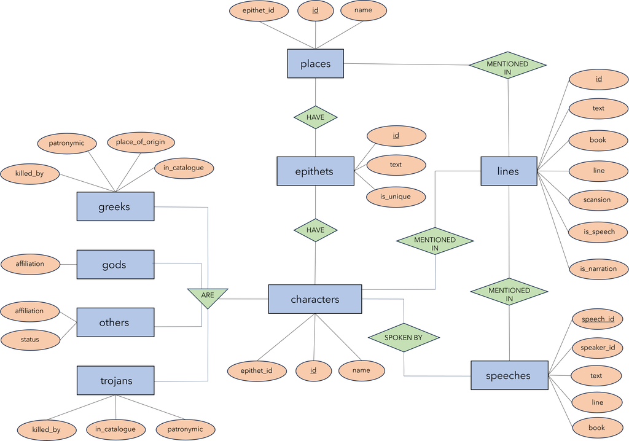

It might look a bit complicated, but the basic idea is that each of the blue rectangles represents a different table or CSV. It has fields (or columns) represented by the orange ovals. And it’s connected to other tables through the relationships indicated by the green diamonds and triangle.

The star player of this model is the `lines` table, which contains every line in the M.L. West edition of the *Iliad*, along with information about its book, line number, scansion, and whether or not it’s a spoken or narrative line. This is important for determining the information in the `speeches` table, which contains the subset of lines in `lines` that are spoken by the characters.

In a previous class, I created the `lines` and `speeches` tables. But to progress the rest of the data prep for my thesis, I’ve got to start working on the other tables. Next on the task list is to figure out `places` and `characters`. Both of these tables don’t actually include verbatim lines from the *Iliad*, but rather all the proper names in the text that can be classified as a person or a place. (I will use the word “character” and “person” interchangeably for the rest of this report to refer to a character in the *Iliad*, whether they are an actual human, god, or other entity.)

## Now then. Let’s get coding.

```r
# The whole Iliad, in Excel-lent condition
lines <- read_excel("iliad.xlsx")
# head(lines)

# Filter for Book 1, as a tester
book1_lines <- lines %>% filter(book == 1) %>% select(text, line)
```

This project has taught me that regular expressions work on Greek. In hindsight, I don’t know why I assumed it wouldn’t, since regexes (regenges?) just match characters. This is what happens when we only program in English.

This regular expression took way too long to figure out. After a few fruitless searches through Wikipedia for what on earth the Unicode for the capital-letters WITH diacritics were, I ended up just adding them to the end of the first `[]`. If it works, it works!

```r
test_lines <- head(book1_lines)
proper_names_test <- test_lines %>%
  mutate(proper_name = str_extract_all(text, "\\b[Α-ΩἉἈἌἍἙἘἜἝἩἨἬἭἹἸἼἽὉὈὌὍὙὝὩὨὬὭ][\\w\\u0300-\\u036F\u1F00-\u1FFF]+\\b")) %>%
  unnest(cols = c(proper_name)) %>%
  select(proper_name, line) # we don't need the text column anymore
```

Nice. Let’s check it out:

```r
proper_names_test
```

```
## # A tibble: 6 × 2
##   proper_name  line
##   <chr>       <dbl>
## 1 Μῆνιν           1
## 2 Πηληϊάδεω       1
## 3 Ἀχιλῆος         1
## 4 Ἀχαιοῖς         2
## 5 Ἄϊδι            3
## 6 Διὸς            5
```

If we compare to the original lines, we can see that the proper-name extraction actually worked! Three in line 1, and one each in lines 2, 3, and 5.

```r
test_lines
```

```
## # A tibble: 6 × 2
##   text                                        line
##   <chr>                                      <dbl>
## 1 Μῆνιν ἄειδε, θεά, Πηληϊάδεω Ἀχιλῆος,           1
## 2 οὐλομένην, ἣ μυρί’ Ἀχαιοῖς ἄλγε’ ἔθηκεν,       2
## 3 πολλὰς δ’ ἰφθίμους ψυχὰς Ἄϊδι προΐαψεν         3
## 4 ἡρώων, αὐτοὺς δὲ ἑλώρια τεῦχε κύνεσσιν         4
## 5 οἰωνοῖσί τε πᾶσι, Διὸς δ’ ἐτελείετο βουλή,     5
## 6 ἐξ οὗ δὴ τὰ πρῶτα διαστήτην ἐρίσαντε           6
```

We can safely say that the proper-name extraction works, so let’s go ahead and proper-name extract the rest of Book 1 (and heck, why not the rest of the Iliad, while we’re at it?):

```r
book1_proper_names <- book1_lines %>%
  mutate(proper_name = str_extract_all(text, "\\b[Α-ΩἉἈἌἍἙἘἜἝἩἨἬἭἹἸἼἽὉὈὌὍὙὝὩὨὬὭ][\\w\\u0300-\\u036F\u1F00-\u1FFF]+\\b")) %>%
  unnest(cols = c(proper_name)) %>%
  select(proper_name, line)

iliad_proper_names <- lines %>%
  mutate(proper_name = str_extract_all(text, "\\b[Α-ΩἉἈἌἍἙἘἜἝἩἨἬἭἹἸἼἽὉὈὌὍὙὝὩὨὬὭ][\\w\\u0300-\\u036F\u1F00-\u1FFF]+\\b")) %>%
  unnest(cols = c(proper_name)) %>%
  select(proper_name, line, book)
```

How many proper names did we have?

```r
nrow(book1_proper_names); nrow(iliad_proper_names)
```

```
## [1] 324
```

```
## [1] 9119
```

Wow. 324 proper names in Book 1 alone and 9,119 proper names in the rest of the Iliad. Let’s check out some distribution patterns. First, I want to see how many proper names there are per book of the Iliad:

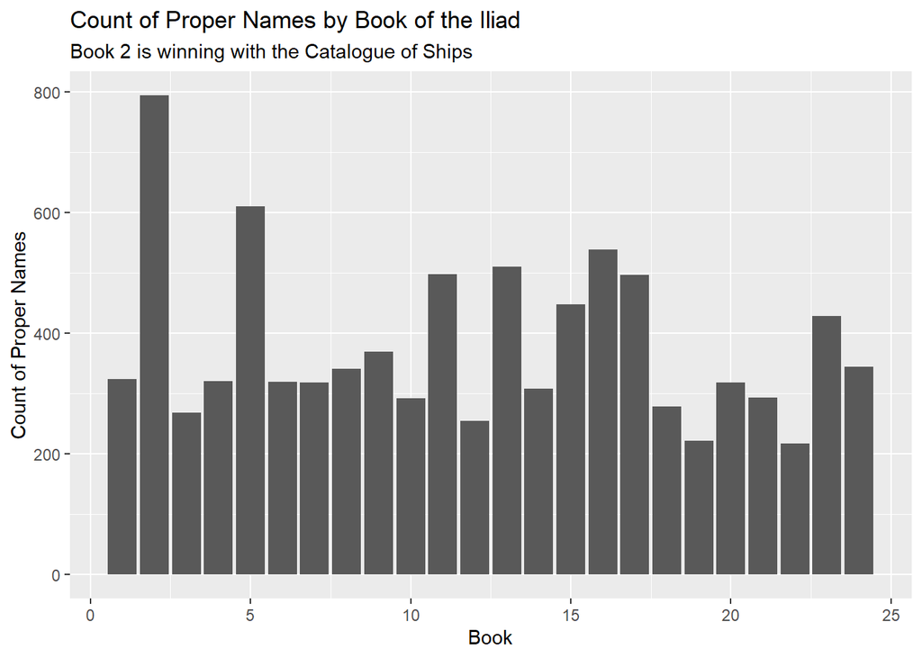

```r
names_per_book <- iliad_proper_names %>% group_by(book) %>% summarise(name_count = n())

ggplot(data=names_per_book, aes(x=book, y=name_count)) +
  geom_col() +
  labs(title="Count of Proper Names by Book of the Iliad",
       subtitle="Book 2 is winning with the Catalogue of Ships",
       x="Book",
       y="Count of Proper Names")
```

This is actually really funny. There’s a noticeable spike in proper names in Book 2, which contains the infamous “Catalogue of Ships”. For those unfamiliar with the *Iliad*, this is pretty much a roll-call of all the characters in the entire epic. All of them. Almost every character on the Greek and Trojan sides is mentioned in this book, which is probably why the count is nearly 800.

I think it’s interesting that there’s a bit of a spike in names (around 600) in Book 5, which is the book of Diomedes’ Athena-fueled rampage through the Trojan army. (The proper term for this is his *aristeia*.) Interestingly, a cursory glance through the source material shows that many of these names are the men that Diomedes and others in the Greek army kill. There might be an interesting correlation between the number of proper names and the number of deaths. However, that’s an analysis for another time.

Let’s look more closely at Book 1. This is where we get our introduction to the quarrel between Agamemnon and Achilles that kicks off the rest of the epic. It’ll be interesting to see where the concentration of proper names is here.

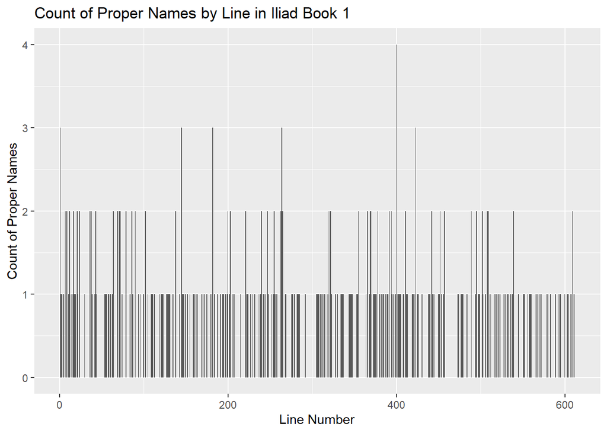

```r
b1_names_by_lines <- book1_proper_names %>%
  group_by(line) %>%
  summarise(name_count = n())

ggplot(data=b1_names_by_lines, aes(x=line, y=name_count)) +
  geom_col() +
  labs(title="Count of Proper Names by Line in Iliad Book 1",
       x="Line Number",
       y="Count of Proper Names")
```

```r
nrow(b1_names_by_lines); nrow(book1_lines)
```

```
## [1] 264
```

```
## [1] 611
```

Yikes. The graph is… ugly, but let’s see what we can glean from it. Just under half the lines in Book 1 actually have at least one proper name in them, ranging from 1 to 4. Interestingly, we have only a handful of 3’s and one 4. Let’s check them out.

```r
over_3 <- b1_names_by_lines %>% filter(name_count >= 3)

over_3
```

```
## # A tibble: 6 × 2
##    line name_count
##   <dbl>      <int>
## 1     1          3
## 2   145          3
## 3   182          3
## 4   264          3
## 5   400          4
## 6   423          3
```

We saw line 1 earlier, but it wouldn’t hurt to revisit it when we go exploring the other lines as well:

```r
book1_lines_over_3 <- book1_lines %>% filter(line %in% over_3$line)
book1_lines_over_3
```

```
## # A tibble: 6 × 2
##   text                                          line
##   <chr>                                        <dbl>
## 1 Μῆνιν ἄειδε, θεά, Πηληϊάδεω Ἀχιλῆος,             1
## 2 ἠ’ Αἴας ἠ’ Ἰδομενεὺς ἢ δῖος Ὀδυσσεύς,          145
## 3 ὣς ἔμ’ ἀφαιρεῖται Χρυσηΐδα Φοῖβος Ἀπόλλων,     182
## 4 Καινέα τ’ Ἐξάδιόν τε καὶ ἀντίθεον Πολύφημον.   264
## 5 Ἥρη τ’ ἠδὲ Ποσειδάων καὶ Παλλὰς Ἀθήνη,         400
## 6 Ζεὺς γὰρ ἐς Ὠκεανὸν μετ’ ἀμύμονας Αἰθιοπῆας    423
```

Uh-oh. There are two problems with this, and it’s not the code. Let’s address the first problem. All the text is in Greek. If you’re well-versed in Ancient Greek, not a problem. If you know your way around a Greek alphabet and don’t mind squinting into the text for more than a few minutes, not a huge problem. But if you’re not familiar with Greek at all, then there’s a readability issue. How do you confirm whether the proper names were correctly counted? Maybe it would help to have English equivalents for any proper names that are identified by the proper-name extraction, along with clarification on whether it’s a person or a place.

The second problem: Not all the R-identified proper names are words that *should* be capitalized. For example, the first word of the first line is Μῆνιν, which is the Greek word for “wrath” or “anger”. It’s not a person or a place! This is a problem that’s slightly harder to solve, and possibly outside the scope of what I’d like to do for this quarter. Some editions of the text of the *Iliad* add capitalization to the beginnings of arbitrarily-divided “stanzas” or sections, or to the beginnings of sentences. The version of the text I’m using happens to include capitalization for words that are not people- or place-names.

Given the time constraints of this project, I won’t be able to create a more sophisticated way of filtering out non-person or place names, so we’ll keep them as is. Further, given that there are over 9,000 proper names mentioned in the *Iliad* and only a few weeks to complete this project, I don’t think I’ll be able to annotate them all, either.

Instead, let’s walk through the process using the first 50 lines of Book 1 as an example. Here are the columns I added:

1. **Transliteration**. Here, I transliterate the Greek letters to English letters without changing the grammatical form of the original Greek.
2. **XML Transliteration**. Here, I use the [Greek text-entry alphabet on Perseus](https://www.perseus.tufts.edu/hopper/morph?l=*%29axilh%3Dos&la=greek&can=*%29axilh%3Dos0&prior=*phlhi+a/dew&d=Perseus:text:1999.01.0133:book=1:card=1&i=1) to transliterate the Greek (with diacritics) to the beta codes used in the Perseus XML.
3. **English Translation**. A basic translation to English
4. **Identifier**. Is the name for a person, a place, or is it an editorial capitalization?
5. **Case**. Greek has five cases that nouns and adjectives can take to reflect their function in a sentence. Since proper names are people and places (and sometimes other things, due to the aforementioned editorial problem), they are all nouns. Some places offer their names to demonyms, such as “Olympus” to “Olympian”.
6. **Number**. Greek has a singular, dual, and plural. These are also properties of nouns and adjectives.

```r
b1_names_50 <- book1_proper_names %>% filter(line <= 50)
write.csv(b1_names_50, "b1_names_50.csv", fileEncoding="utf-8")
```

Ugh. Forgot that MS Excel can be a hassle around utf-8 encoding sometimes.

[figure not shown]

Let’s just edit in VS Code instead. Much better.

[figure not shown]

## SOME EDITING LATER…

```r
b1_full_50 <- read.csv("b1_full_50.csv")
head(b1_full_50)
```

```
##   id proper_name line transliteration xml_transliteration translation
## 1  1       Μῆνιν    1           Menin             *mh=nin       anger
## 2  2   Πηληϊάδεω    1       Peleiadeo        *phlhi+a/dew   Peleiades
## 3  3     Ἀχιλῆος    1        Achileos          *)axilh=os    Achilles
## 4  4     Ἀχαιοῖς    2        Achaiois          *)axaioi=s    Achaeans
## 5  5        Ἄϊδι    3            Aidi            *)/ai+di       Hades
## 6  6        Διὸς    5            Dios             *dio\\s        Zeus
##   identifier       case   number
## 1  editorial accusative singular
## 2     person   genitive singular
## 3     person   genitive singular
## 4     person     dative   plural
## 5     person     dative singular
## 6     person   genitive singular
```

Fun times! Now we have a lot more information about each of the names themselves, which can be used for further analysis. With the caveat that we’re only looking at the first 50 lines of Book 1 of the *Iliad* and that this is by no means a representative sample of the 15,000+ lines of the entire epic… let’s see what we can plot!

We might be interested in comparing the number of proper names that are labeled as a `person` or a `place`…

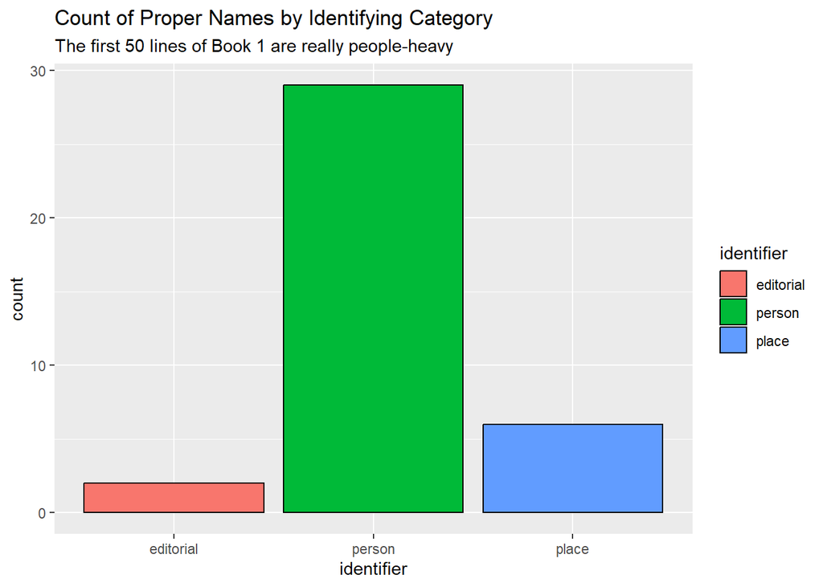

```r
b1_by_identifier <- b1_full_50 %>% group_by(identifier) %>% summarise(count = n())
ggplot(data=b1_by_identifier, aes(x=identifier, y=count, fill=identifier)) +
  geom_col(color="black") +
  labs(title="Count of Proper Names by Identifying Category",
       subtitle="The first 50 lines of Book 1 are really people-heavy")
```

Similarly, we might want to see in what case the proper names are most used…

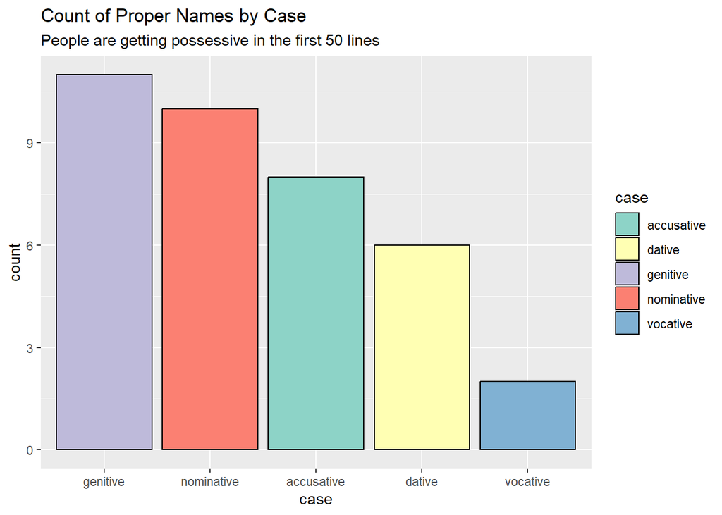

```r
b1_by_case <- b1_full_50 %>% group_by(case) %>% summarise(count = n())
ggplot(data=b1_by_case, aes(x=reorder(case, -count), y=count, fill=case)) +
  geom_col(color="black") +
  labs(title="Count of Proper Names by Case",
       subtitle="People are getting possessive in the first 50 lines",
       x="case") +
  scale_fill_brewer(palette="Set3")
```

If we wanted, we could also see who was getting called out the most, too!

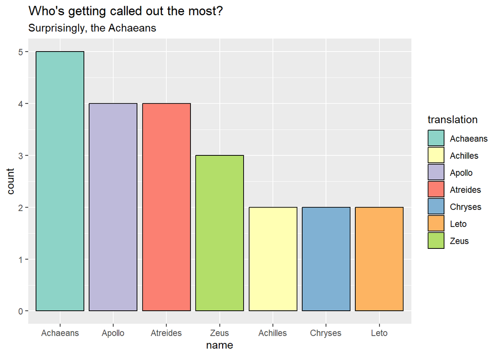

```r
callouts <- b1_full_50 %>% group_by(translation) %>%
  summarise(count = n()) %>% filter(count > 1)

ggplot(data=callouts, aes(x=reorder(translation, -count), y=count, fill=translation)) +
  geom_col(color="black") +
  labs(title="Who's getting called out the most?",
       subtitle="Surprisingly, the Achaeans",
       x="name") +
  scale_fill_brewer(palette="Set3")
```

## Closing Thoughts and Future Directions

Of course, there’s still a lot of work to be done here. For one, the rest of the proper names (all 9,119 of them) still need annotations, which might be time-consuming. I will also need to filter out the editorial capitalizations. Further, in the endgame relational data model, we saw that place names and people names were separated into two different tables. It will be relatively easy to apply a filter for just “place” or “person”, then write the corresponding dataframe to a CSV. The only issue is time, and the fact that I didn’t have enough of it to flesh out the rest of the proper-names table.

That being said, I find that this approach shows promise, even if it’s a little slow. The most difficult part of this step was figuring out the regex that would give all the proper names in Greek, while navigating diacritics when it comes to the vowel variations. The rest of it was pretty straightforward.